# **Easy Visa**

## **Context**

Business communities in the United States are facing high demand for human resources, but one of the constant challenges is identifying and attracting the right talent, which is perhaps the most important element in remaining competitive. Companies in the United States look for hard-working, talented, and qualified individuals both locally as well as abroad. The Immigration and Nationality Act (INA) of the US permits foreign workers to come to the United States to work on either a temporary or permanent basis. The act also protects US workers against adverse impacts on their wages or working conditions by ensuring US employers' compliance with statutory requirements when they hire foreign workers to fill workforce shortages. The immigration programs are administered by the Office of Foreign Labor Certification (OFLC). OFLC processes job certification applications for employers seeking to bring foreign workers into the United States and grants certifications in those cases where employers can demonstrate that there are not sufficient US workers available to perform the work at wages that meet or exceed the wage paid for the occupation in the area of intended employment.

## **Objective**

In FY 2016, the OFLC processed 775,979 employer applications for 1,699,957 positions for temporary and permanent labor certifications. This was a nine percent increase in the overall number of processed applications from the previous year. The process of reviewing every case is becoming a tedious task as the number of applicants is increasing every year. The increasing number of applicants every year calls for a Machine Learning based solution that can help in shortlisting the candidates having higher chances of VISA approval. OFLC has hired the firm EasyVisa for data-driven solutions. You as a data scientist at EasyVisa have to analyze the data provided and, with the help of a classification model:

1. Facilitate the process of visa approvals.
2. Recommend a suitable profile for the applicants for whom the visa should be certified or denied based on the drivers that significantly influence the case status.

## **Data Description**

The data contains the different attributes of the employee and the employer. The detailed data dictionary is given below.

| Column Name | Dexcription |
| --- | --- |
| case_id | ID of each visa application |
| continent | Information of continent of the employee |
| education_of_employee | Information of education of the employee |
| has_job_experience | Does the employee has any job experience? Y= Yes; N = No |
| requires_job_training | Does the employee require any job training? Y = Yes; N = No |
| no_of_employees | Number of employees in the employer's company |
| yr_of_estab | Year in which the employer's company was established |
| region_of_employment | Information of foreign worker's intended region of employment in the US. |
| prevailing_wage | Average wage paid to similarly employed workers in a specific occupation in the area of intended employment. The purpose of the prevailing wage is to ensure that the foreign worker is not underpaid co… |
| unit_of_wage | Unit of prevailing wage. Values include Hourly, Weekly, Monthly, and Yearly. |
| full_time_position | Is the position of work full-time? Y = Full-Time Position N = Part-Time Position |
| case_status | Flag indicating if the Visa was certified or denied |

```python
# Data manipulation libraries
import pandas as pd          # For data manipulation and analysis
import numpy as np          # For numerical operations

# Data visualization libraries
import matplotlib.pyplot as plt          # For creating static visualizations
# To display plots in Jupyter notebook
%matplotlib inline
import seaborn as sns                    # For enhanced statistical visualizations
from adjustText import adjust_text

# Machine Learning model and utilities from scikit-learn
from sklearn.model_selection import train_test_split, GridSearchCV, RandomizedSearchCV, StratifiedKFold, cross_val_score
from sklearn.linear_model import LogisticRegression
from sklearn.tree import DecisionTreeClassifier
from sklearn import tree
from sklearn.ensemble import BaggingClassifier, RandomForestClassifier, AdaBoostClassifier, GradientBoostingClassifier

import sklearn
from xgboost import XGBClassifier

from itertools import product
import scipy.stats as ss

# Model evaluation metrics and visualization tools
from sklearn import metrics
from sklearn.metrics import (
    f1_score,                    # For F1 score calculation
    accuracy_score,              # For accuracy calculation
    recall_score,                # For recall calculation
    precision_score,             # For precision calculation
    ConfusionMatrixDisplay,      # For visualizing confusion matrix
    make_scorer,                 # For creating custom scoring metrics
    confusion_matrix             # For creating confusion matrix
)

# To undersample and oversample the data
from imblearn.over_sampling import SMOTE
from imblearn.under_sampling import RandomUnderSampler

# Suppress warnings for cleaner output
import warnings
warnings.filterwarnings("ignore")    # To ignore unnecessary warnings during execution
```

```python
# Reading the dataset
df = pd.read_csv('EasyVisa.csv')
df.head()
```

|  | case_id | continent | education_of_employee | has_job_experience | requires_job_training | no_of_employees | yr_of_estab | region_of_employment | prevailing_wage | unit_of_wage | full_time_position | case_status |
| --- | --- | --- | --- | --- | --- | --- | --- | --- | --- | --- | --- | --- |
| 0 | EZYV01 | Asia | High School | N | N | 14513 | 2007 | West | 592.2029 | Hour | Y | Denied |
| 1 | EZYV02 | Asia | Master's | Y | N | 2412 | 2002 | Northeast | 83425.6500 | Year | Y | Certified |
| 2 | EZYV03 | Asia | Bachelor's | N | Y | 44444 | 2008 | West | 122996.8600 | Year | Y | Denied |
| 3 | EZYV04 | Asia | Bachelor's | N | N | 98 | 1897 | West | 83434.0300 | Year | Y | Denied |
| 4 | EZYV05 | Africa | Master's | Y | N | 1082 | 2005 | South | 149907.3900 | Year | Y | Certified |

```python
df.info()
```

```
<class 'pandas.core.frame.DataFrame'>
RangeIndex: 25480 entries, 0 to 25479
Data columns (total 12 columns):
 #   Column                 Non-Null Count  Dtype
---  ------                 --------------  -----
 0   case_id                25480 non-null  object
 1   continent              25480 non-null  object
 2   education_of_employee  25480 non-null  object
 3   has_job_experience     25480 non-null  object
 4   requires_job_training  25480 non-null  object
 5   no_of_employees        25480 non-null  int64
 6   yr_of_estab            25480 non-null  int64
 7   region_of_employment   25480 non-null  object
 8   prevailing_wage        25480 non-null  float64
 9   unit_of_wage           25480 non-null  object
 10  full_time_position     25480 non-null  object
 11  case_status            25480 non-null  object
dtypes: float64(1), int64(2), object(9)
memory usage: 2.3+ MB
```

🔎 **`Observations:`**

- The dataset contains **25,480 entries** with **12 columns**.
- Most columns (**9 out of 12**) are **categorical**, while **3 columns** are **numerical** (`no_of_employees`, `yr_of_estab`, `prevailing_wage`).
- **No missing values** are present, ensuring clean data for modeling.
- `case_status` is the **target variable**, determining the outcome of the visa application.

```python
# Lets convert the "object" type features into "categorical" features
for feature in df.columns:
    if df[feature].dtype == 'object':
        df[feature] = pd.Categorical(df[feature])
```

```python
# Dropping the case_id column as it is not required
df.drop(columns=['case_id'],inplace=True)
```

```python
# Categorizing the features into numerical and categorical
num_col = df.select_dtypes(include='number').columns
cat_col = df.select_dtypes(include='category').columns
print("Numeric Columns: ", num_col)
print("Categorical Columns: ", cat_col)
```

```
Numeric Columns:  Index(['no_of_employees', 'yr_of_estab', 'prevailing_wage'], dtype='object')
Categorical Columns:  Index(['continent', 'education_of_employee', 'has_job_experience',
       'requires_job_training', 'region_of_employment', 'unit_of_wage',
       'full_time_position', 'case_status'],
      dtype='object')
```

```python
df.describe(include='all').T
```

|  | count | unique | top | freq | mean | std | min | 25% | 50% | 75% | max |
| --- | --- | --- | --- | --- | --- | --- | --- | --- | --- | --- | --- |
| continent | 25480 | 6 | Asia | 16861 | NaN | NaN | NaN | NaN | NaN | NaN | NaN |
| education_of_employee | 25480 | 4 | Bachelor's | 10234 | NaN | NaN | NaN | NaN | NaN | NaN | NaN |
| has_job_experience | 25480 | 2 | Y | 14802 | NaN | NaN | NaN | NaN | NaN | NaN | NaN |
| requires_job_training | 25480 | 2 | N | 22525 | NaN | NaN | NaN | NaN | NaN | NaN | NaN |
| no_of_employees | 25480.0 | NaN | NaN | NaN | 5667.04321 | 22877.928848 | -26.0 | 1022.0 | 2109.0 | 3504.0 | 602069.0 |
| yr_of_estab | 25480.0 | NaN | NaN | NaN | 1979.409929 | 42.366929 | 1800.0 | 1976.0 | 1997.0 | 2005.0 | 2016.0 |
| region_of_employment | 25480 | 5 | Northeast | 7195 | NaN | NaN | NaN | NaN | NaN | NaN | NaN |
| prevailing_wage | 25480.0 | NaN | NaN | NaN | 74455.814592 | 52815.942327 | 2.1367 | 34015.48 | 70308.21 | 107735.5125 | 319210.27 |
| unit_of_wage | 25480 | 4 | Year | 22962 | NaN | NaN | NaN | NaN | NaN | NaN | NaN |
| full_time_position | 25480 | 2 | Y | 22773 | NaN | NaN | NaN | NaN | NaN | NaN | NaN |
| case_status | 25480 | 2 | Certified | 17018 | NaN | NaN | NaN | NaN | NaN | NaN | NaN |

🔎 **Observations : Description of the dataset**

1. **Continent**: Data spans 6 continents, with Asia being the most frequent (16,861 cases).
2. **Education of Employee**: Employees have 4 distinct education levels, with Bachelor's degrees being the most common (10,234 cases).
3. **Job Experience**: Two categories exist (`Y` or `N`), with most employees having job experience (`Y`, 14,802 cases).
4. **Job Training Requirement**: Most positions do not require job training (`N`, 22,525 cases).
5. **Number of Employees**:
   - Mean: 5,667 employees per company.
   - Range: -26 to 602,069 employees (negative values may indicate errors).
6. **Year of Establishment**:
   - Mean: 1979.
   - Range: From 1800 to 2016.
7. **Region of Employment**: Data spans 5 regions, with the Northeast region being the most frequent (7,195 cases).
8. **Prevailing Wage**:
   - Mean: $74,455.
   - Range: $2.14 to $319,210.
   - Significant variability in wages.
9. **Unit of Wage**: Wages are categorized into 4 units, with "Year" being the most common (22,962 cases).
10. **Full-Time Positions**: Two categories exist (`Y` or `N`), with most positions being full-time (`Y`, 22,773 cases).
11. **Case Status**: Two statuses exist (`Certified` or `Denied`), with most cases certified (17,018 cases).

```python
# Number of employees cannot be negative so taking absolute value; as it might be typing error
df['no_of_employees'] = abs(df['no_of_employees'])
```

```python
# checking for missing values
df.isnull().sum()
```

```
continent                0
education_of_employee    0
has_job_experience       0
requires_job_training    0
no_of_employees          0
yr_of_estab              0
region_of_employment     0
prevailing_wage          0
unit_of_wage             0
full_time_position       0
case_status              0
dtype: int64
```

- Dataset contains no null values

```python
for col in cat_col:
    print("----------------------\n")
    print(df[col].value_counts())
```

```
----------------------

continent
Asia             16861
Europe            3732
North America     3292
South America      852
Africa             551
Oceania            192
Name: count, dtype: int64
----------------------

education_of_employee
Bachelor's     10234
Master's        9634
High School     3420
Doctorate       2192
Name: count, dtype: int64
----------------------

has_job_experience
Y    14802
N    10678
Name: count, dtype: int64
----------------------

requires_job_training
N    22525
Y     2955
Name: count, dtype: int64
----------------------

region_of_employment
Northeast    7195
South        7017
West         6586
Midwest      4307
Island        375
Name: count, dtype: int64
----------------------

unit_of_wage
Year     22962
Hour      2157
Week       272
Month       89
Name: count, dtype: int64
----------------------

full_time_position
Y    22773
N     2707
Name: count, dtype: int64
----------------------

case_status
Certified    17018
Denied        8462
Name: count, dtype: int64
```

🔎 **`Observations:`**

## 📊 **Univariate Analysis**

```python
def univariate_analysis(data,col,cat=False, legend=False):
    sns.set_palette(['darkturquoise'])
    colors = ['lightcoral','lightsalmon','palegoldenrod','lightgreen','lightblue','lightcyan']

    if cat and legend:
        fig, ax = plt.subplots(1, 2, figsize=(12, 4))

        # Countplot
        sns.countplot(data=data, x=col, ax=ax[0])
        ax[0].set_title(f'{col} Distribution (Countplot)')

        # Pie chart data
        value_counts = data[col].value_counts()
        sizes = value_counts.values
        labels = value_counts.index

        chart_colors = colors[:len(labels)]

        # Create the pie chart
        wedges, texts = ax[1].pie(
            sizes,
            labels=None,  # Do not display labels directly on the pie chart
            autopct=None,  # Show percentages on the wedges
            startangle=90,
            colors=chart_colors,
            wedgeprops={'edgecolor': 'white', 'linewidth': 2}
        )

        # Add a legend to the right of the pie chart
        ax[1].legend(
            wedges,  # Use the wedges as handles for the legend
            [f"{label}: {size / sum(sizes) * 100:.1f}%" for label, size in zip(labels, sizes)],  # Custom labels with percentages
            title="Continents",  # Title for the legend
            loc="center left",  # Position the legend to the right of the pie chart
            bbox_to_anchor=(1, 0.5),  # Adjust position (x=1 places it outside the chart)
        )

        ax[1].set_title(f'{col} Distribution (Pie Chart)')

        plt.tight_layout()
        return
    elif cat and not legend:
        fig, ax = plt.subplots(1, 2, figsize = (10,3));

        sns.countplot(data = data, x = col, ax = ax[0])
        ax[0].set_title(f'{col} Distribution (Countplot)');

        # Plotting Pie Chart
        value_counts = data[col].value_counts()
        sizes = value_counts.values
        labels = value_counts.index

        chart_colors = colors[:len(labels)]

        ax[1].pie(
            sizes,
            labels=labels,
            autopct='%1.1f%%',
            startangle=90,
            colors=chart_colors,
            wedgeprops={'edgecolor': 'white', 'linewidth': 2}
        );
        ax[1].set_title(f'{col} Distribution (Pie Chart)');
        return
    fig, ax = plt.subplots(1, 2, figsize = (10,3));

    sns.histplot(data = data, x = col, ax = ax[0], kde=True)
    ax[0].set_title(f'{col} Distribution (Histogram)');
    ax[0].axvline(data[col].mean(), c = 'r', linestyle='--', linewidth=2, label=f'Mean: {data[col].mean():.2f}')
    ax[0].axvline(data[col].median(), c = 'y', linestyle='-', linewidth=2, label=f'Median: {data[col].median():.2f}')
    ax[0].legend(loc='upper right')

    sns.boxplot(data = data, x = col, ax = ax[1])
    ax[1].set_title(f'{col} Distribution (Boxplot)');
```

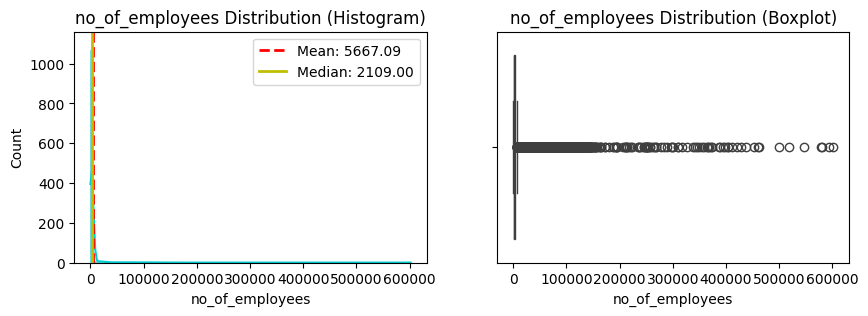

```python
univariate_analysis(df,'no_of_employees')
```

🔎 **Observations:**

1. **Skewed Distribution**:
   - The histogram shows that the distribution of `no_of_employees` is highly right-skewed, with most companies having a relatively small number of employees.
   - A few companies have extremely high employee counts, creating long tails in the data.
2. **Mean vs Median**:
   - The mean number of employees is **5,667.09**, while the median is significantly lower at **2,109**.
   - This indicates the presence of outliers (companies with very high employee counts) pulling the mean upward.
3. **Outliers**:
   - The boxplot highlights numerous outliers, with employee counts going up to 600,000.
   - These outliers represent large organizations or companies with massive workforces.
4. **Majority of Cases**:
   - Most companies have fewer than 10,000 employees, as seen from the concentration of values on the left side of the histogram.

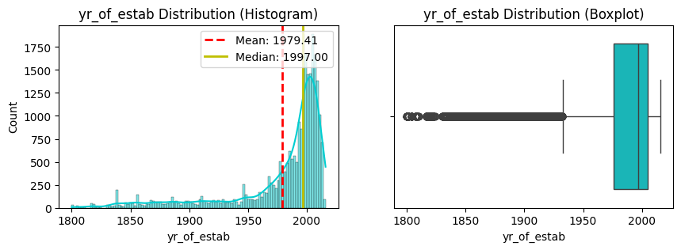

```python
univariate_analysis(df,'yr_of_estab')
```

🔎 **Observations:**

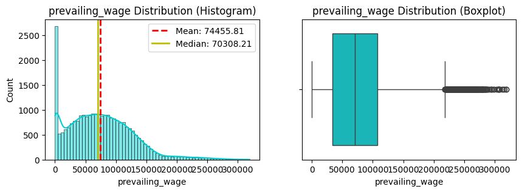

```python
univariate_analysis(df,'prevailing_wage')
```

🔎 **Observations:**

1. **Right-Skewed Distribution**:
   - The histogram shows that the distribution of `prevailing_wage` is **right-skewed**, with most wages concentrated at lower values.
   - A long tail extends to higher wages, indicating the presence of a few high-paying jobs.
2. **Mean vs Median**:
   - The mean prevailing wage is **74,455.81**, while the median is slightly lower at **70,308.21**.
   - The difference between the mean and median confirms the right-skewed nature, as higher wages pull the mean upward.
3. **Outliers**:
   - The boxplot highlights several outliers with wages exceeding **225,000 USD**, going up to approximately **319,210 USD**.
   - These outliers represent rare, high-paying positions compared to the majority of jobs.
4. **Majority of Cases**:
   - Most prevailing wages fall between **34,015 USD (25th percentile)** and **107,735 USD (75th percentile)**, as indicated by the interquartile range (IQR).
   - This suggests that most jobs offer wages within this range.
5. **Data Spread**:
   - The boxplot indicates that the majority of data points are tightly clustered within the IQR, but there is significant variability due to outliers.

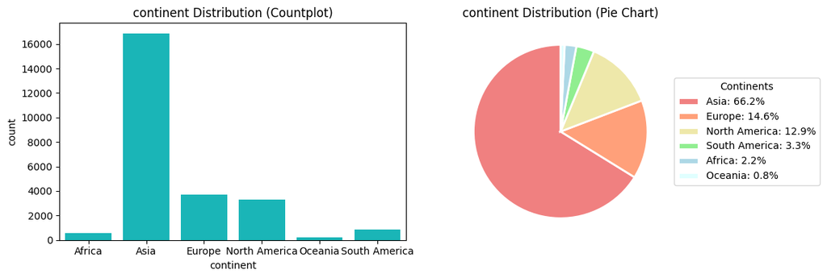

```python
univariate_analysis(df,'continent',cat=True, legend=True)
```

🔎 **Observations:**

1. **Asia Dominates**:
   - Asia accounts for the majority of cases, with **66.2%** of the total dataset.
   - This indicates a significant focus on Asian countries in visa or employment-related applications.
2. **Europe and North America**:
   - Europe contributes **14.6%**, while North America accounts for **12.9%** of the data.
   - These continents represent notable portions but are far less dominant compared to Asia.
3. **Minimal Representation**:
   - Africa (**2.2%**), South America (**3.3%**), and Oceania (**0.8%**) have very low representation in the dataset.
   - This suggests limited visa or employment activity from these regions.
4. **Skewed Distribution**:
   - The distribution is heavily skewed towards Asia, as seen in both the countplot and pie chart.
   - Other continents have significantly fewer cases, creating an imbalanced dataset.

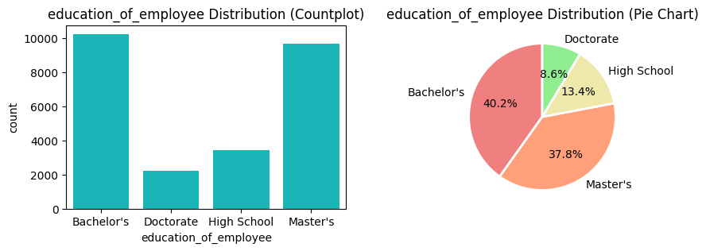

```python
univariate_analysis(df,'education_of_employee',cat=True)
```

🔎 **Observations:**

1. **Bachelor's Degree Dominates**:
   - The majority of employees hold a **Bachelor's degree**, accounting for **40.2%** of the dataset (approximately 10,234 cases).
   - This indicates that most visa or employment applications are from individuals with undergraduate education.
2. **Master's Degree is Second**:
   - Employees with a **Master's degree** make up **37.8%** of the dataset, closely following Bachelor's degree holders.
   - Together, Bachelor's and Master's degree holders form the majority, accounting for nearly **78%** of the dataset.
3. **Lower Representation of High School and Doctorate**:
   - Employees with a **High School education** account for **13.4%**, while those with a **Doctorate** represent only **8.6%**.
   - This suggests that fewer applicants come from these educational backgrounds.
4. **Skewed Distribution**:
   - The distribution is heavily skewed toward higher education levels (Bachelor's and Master's degrees), indicating that most positions likely require advanced qualifications.
5. **Educational Trends**:
   - The dataset reflects a trend where individuals with higher education (Bachelor's and Master's) dominate visa or employment applications, while those with lower or specialized education (High School or Doctorate) are less frequent.

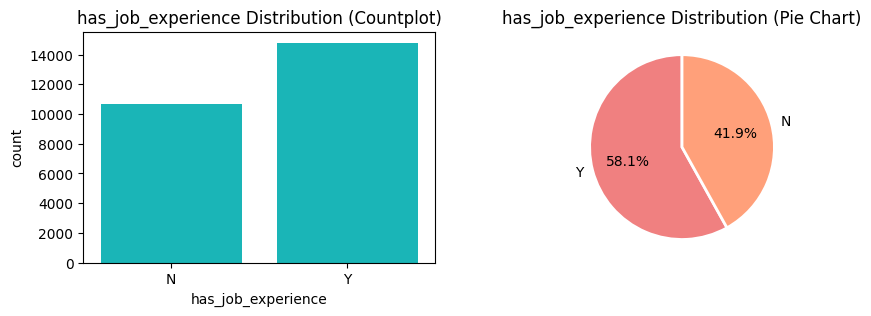

```python
univariate_analysis(df, 'has_job_experience',cat=True)
```

🔎 **Observations:**

1. **Majority Have Job Experience**:
   - **58.1%** of the individuals in the dataset have job experience (`Y`), which amounts to approximately **14,802 cases**.
   - This indicates that a significant portion of applicants are experienced professionals.
2. **Significant Proportion Without Experience**:
   - **41.9%** of the individuals do not have job experience (`N`), which corresponds to around **10,678 cases**.
   - While fewer than those with experience, this is still a substantial portion of the dataset.
3. **Preference for Experienced Candidates**:
   - The higher proportion of individuals with job experience suggests that many positions or visa applications may prefer or require prior work experience.
4. **Balanced Distribution**:
   - Although there is a preference for experienced candidates, the dataset shows a relatively balanced distribution between experienced and inexperienced individuals, indicating opportunities for both groups.
5. **Potential Insights for Training**:
   - The presence of a significant number of inexperienced candidates (`N`) could highlight the importance of job training programs for these individuals.

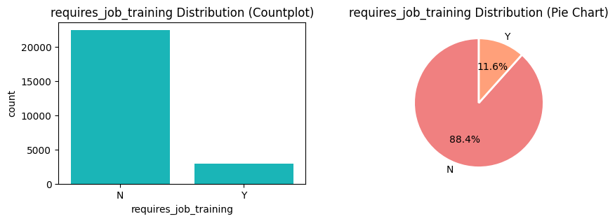

```python
univariate_analysis(df,'requires_job_training',cat=True)
```

🔎 **Observations:**

1. **Most Positions Do Not Require Job Training**:
   - **88.4%** of the cases (`N`) indicate that job training is not required, which corresponds to **22,525 cases**.
   - This suggests that the majority of positions are filled by individuals who already possess the necessary skills.
2. **Few Positions Require Job Training**:
   - Only **11.6%** of the cases (`Y`) require job training, which corresponds to **2,955 cases**.
   - This indicates that a smaller portion of roles cater to individuals who may need additional training.
3. **Skewed Distribution**:
   - The distribution is heavily skewed toward positions that do not require job training (`N`), as seen in both the countplot and pie chart.
4. **Implications for Workforce Readiness**:
   - The dominance of positions not requiring job training suggests that employers prefer hiring candidates who are already skilled and experienced.
   - However, the presence of 11.6% of roles requiring training highlights opportunities for skill development programs or entry-level positions.
5. **Alignment with `has_job_experience`**:
   - This trend aligns with the earlier observation that a majority of candidates have job experience, reducing the need for training.

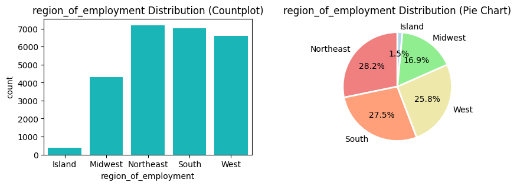

```python
univariate_analysis(df,'region_of_employment',cat=True)
```

🔎 **Observations:**

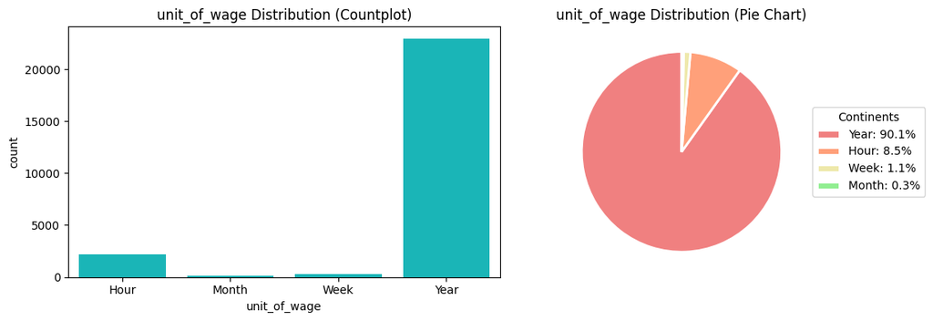

```python
univariate_analysis(df,'unit_of_wage',cat=True, legend=True)
```

🔎 **Observations:**

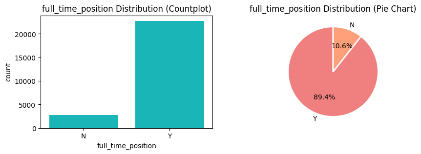

```python
univariate_analysis(df,'full_time_position',cat=True)
```

🔎 **Observations:**

1. **Full-Time Positions Dominate**:
   - **89.4%** of the positions in the dataset are full-time (`Y`), accounting for approximately **22,773 cases**.
   - This indicates that the majority of roles are full-time employment opportunities.
2. **Part-Time Positions Are Limited**:
   - Only **10.6%** of the positions are part-time (`N`), corresponding to approximately **2,707 cases**.
   - This suggests that part-time roles are relatively rare in the dataset.
3. **Skewed Distribution**:
   - The distribution is heavily skewed toward full-time positions, as seen in both the countplot and pie chart.
4. **Employment Type Insights**:
   - The dominance of full-time positions indicates a preference for long-term, stable employment opportunities in the dataset.
   - Part-time positions may cater to specific industries or roles requiring flexible work arrangements.

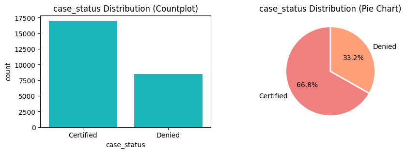

```python
univariate_analysis(df,'case_status',cat=True)
```

🔎 **Observations:**

1. **Majority of Cases Are Certified**:
   - **66.8%** of the cases are **Certified**, accounting for approximately **17,018 cases**.
   - This indicates that the majority of visa or employment applications in the dataset are approved.
2. **Significant Denials**:
   - **33.2%** of the cases are **Denied**, corresponding to approximately **8,462 cases**.
   - While fewer than certified cases, this is still a significant proportion, highlighting that a considerable number of applications face rejection.
3. **Skewed Distribution**:
   - The distribution is skewed toward certified cases, as seen in both the countplot and pie chart.

## 🔗 **Bivariate Analysis**

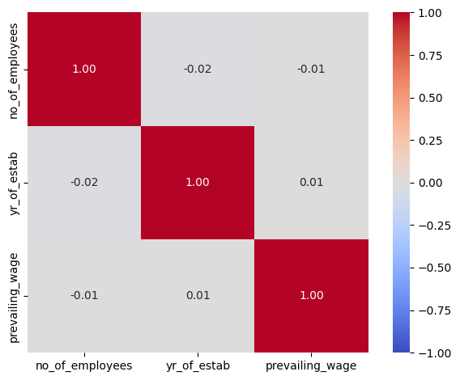

```python
# Creating heatmap with customized parameters
sns.heatmap(df.corr(numeric_only=True),
            annot=True,
            cmap='coolwarm',
            vmin=-1, vmax=1,
            center=0,
            fmt='.2f',
            square=True,
            annot_kws={'size': 10})

plt.tight_layout()
```

🔎 **Observation: There is no correlation between numerical features**

```python
cat_var1 = cat_col
cat_var2 = cat_col

## Let us jump to Chi-Square test
## Creating all possible combinations between the above two variables list
cat_var_prod = list(product(cat_var1,cat_var2, repeat = 1))
cat_var_prod
```

```
[('continent', 'continent'),
 ('continent', 'education_of_employee'),
 ('continent', 'has_job_experience'),
 ('continent', 'requires_job_training'),
 ('continent', 'region_of_employment'),
 ('continent', 'unit_of_wage'),
 ('continent', 'full_time_position'),
 ('continent', 'case_status'),
 ('education_of_employee', 'continent'),
 ('education_of_employee', 'education_of_employee'),
 ('education_of_employee', 'has_job_experience'),
 ('education_of_employee', 'requires_job_training'),
 ('education_of_employee', 'region_of_employment'),
 ('education_of_employee', 'unit_of_wage'),
 ('education_of_employee', 'full_time_position'),
 ('education_of_employee', 'case_status'),
 ('has_job_experience', 'continent'),
 ('has_job_experience', 'education_of_employee'),
 ('has_job_experience', 'has_job_experience'),
 ('has_job_experience', 'requires_job_training'),
 ('has_job_experience', 'region_of_employment'),
 ('has_job_experience', 'unit_of_wage'),
 ('has_job_experience', 'full_time_position'),
 ('has_job_experience', 'case_status'),
 ('requires_job_training', 'continent'),
 ('requires_job_training', 'education_of_employee'),
 ('requires_job_training', 'has_job_experience'),
 ('requires_job_training', 'requires_job_training'),
 ('requires_job_training', 'region_of_employment'),
 ('requires_job_training', 'unit_of_wage'),
 ('requires_job_training', 'full_time_position'),
 ('requires_job_training', 'case_status'),
 ('region_of_employment', 'continent'),
 ('region_of_employment', 'education_of_employee'),
 ('region_of_employment', 'has_job_experience'),
 ('region_of_employment', 'requires_job_training'),
 ('region_of_employment', 'region_of_employment'),
 ('region_of_employment', 'unit_of_wage'),
 ('region_of_employment', 'full_time_position'),
 ('region_of_employment', 'case_status'),
```

[output cut: 9 more lines]

```
 ('full_time_position', 'education_of_employee'),
 ('full_time_position', 'has_job_experience'),
 ('full_time_position', 'requires_job_training'),
 ('full_time_position', 'region_of_employment'),
 ('full_time_position', 'unit_of_wage'),
 ('full_time_position', 'full_time_position'),
 ('full_time_position', 'case_status'),
 ('case_status', 'continent'),
 ('case_status', 'education_of_employee'),
 ('case_status', 'has_job_experience'),
 ('case_status', 'requires_job_training'),
 ('case_status', 'region_of_employment'),
 ('case_status', 'unit_of_wage'),
 ('case_status', 'full_time_position'),
 ('case_status', 'case_status')]
```

```python
## Creating an empty variable and picking only the p value from the output of Chi-Square test
result = []
for i in cat_var_prod:
    if i[0] != i[1]:
        result.append((i[0],i[1],list(ss.chi2_contingency(pd.crosstab(
                                    df[i[0]], df[i[1]])))[1]))
```

```python
chi_test_output = pd.DataFrame(result, columns = ['var1', 'var2',
                                                       'coeff'])
## Using pivot function to convert the above DataFrame into a crosstab
chi_test_output.pivot(index='var1', columns='var2', values='coeff')
```

| var2 var1 | case_status | continent | education_of_employee | full_time_position | has_job_experience | region_of_employment | requires_job_training | unit_of_wage |
| --- | --- | --- | --- | --- | --- | --- | --- | --- |
| case_status | NaN | 8.828798e-74 | 0.000000e+00 | 4.469975e-02 | 1.922560e-206 | 2.338664e-63 | 1.855647e-01 | 5.193385e-240 |
| continent | 8.828798e-74 | NaN | 8.099979e-265 | 1.221838e-95 | 2.753528e-01 | 3.922979e-152 | 1.299618e-76 | 2.590993e-97 |
| education_of_employee | 0.000000e+00 | 8.099979e-265 | NaN | 5.607698e-198 | 1.831258e-01 | 8.097997e-83 | 3.534342e-42 | 4.646221e-27 |
| full_time_position | 4.469975e-02 | 1.221838e-95 | 5.607698e-198 | NaN | 2.425142e-11 | 4.052164e-29 | 2.419138e-62 | 2.179537e-55 |
| has_job_experience | 1.922560e-206 | 2.753528e-01 | 1.831258e-01 | 2.425142e-11 | NaN | 4.711631e-06 | 1.431134e-71 | 7.230630e-100 |
| region_of_employment | 2.338664e-63 | 3.922979e-152 | 8.097997e-83 | 4.052164e-29 | 4.711631e-06 | NaN | 5.016857e-95 | 4.983021e-64 |
| requires_job_training | 1.855647e-01 | 1.299618e-76 | 3.534342e-42 | 2.419138e-62 | 1.431134e-71 | 5.016857e-95 | NaN | 8.856895e-42 |
| unit_of_wage | 5.193385e-240 | 2.590993e-97 | 4.646221e-27 | 2.179537e-55 | 7.230630e-100 | 4.983021e-64 | 8.856895e-42 | NaN |

🔎 **Observation:**

There exists a relationship between two variables if the p-value ≤ 0.05. From the above table, we can observe the following:

- There is a significant association between `case_status` and all other variables except `requires_job_training` (p-value = 0.1856), where no relationship exists.
- `continent` has a relationship with all other variables except `has_job_experience` (p-value = 0.2753).
- `education_of_employee` has a relationship with all other variables except `has_job_experience` (p-value = 0.1831).
- `full_time_position`, `region_of_employment`, `unit_of_wage` are significantly associated with all other variables.

For pairs where the p-value > 0.05, there exists no significant relationship between the variables.

### **Visualizing Categorical Data Relationships**

```python
def plot_stacked_barplot(df, col1, col2 = 'case_status'):
    ct_norm = pd.crosstab(df[col1], df[col2], normalize='index') * 100
    print(ct_norm)
    ct_norm = ct_norm.sort_values(by='Certified', ascending=True)
    ct_norm.plot.bar(stacked=True, figsize=(6, 5), color=['darkturquoise','lightcoral'])
    plt.title(f'Distribution of {col2} Across {col1}', fontsize=14, color='red')
    plt.xlabel(f'{col1}', fontsize=12)
    plt.ylabel('Percentage (%)', fontsize=12)
    plt.legend(title=f'{col2}', loc='best')
    plt.grid(axis='y', linestyle='--', alpha=0.7)
    plt.show()
```

1. **`Case Status by Continent`: This would show how visa or employment applications are distributed across continents for certified and denied cases.**

```
case_status    Certified     Denied
continent
Africa         72.050817  27.949183
Asia           65.310480  34.689520
Europe         79.233655  20.766345
North America  61.877278  38.122722
Oceania        63.541667  36.458333
South America  57.863850  42.136150
```

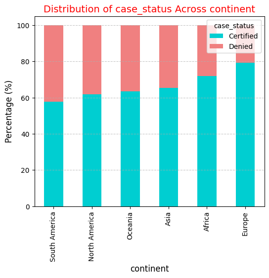

```python
plot_stacked_barplot(df, 'continent', col2 = 'case_status')
```

🔎 **Observations: Distribution of case_status Across continent**

```
case_status            Certified     Denied
education_of_employee
Bachelor's             62.214188  37.785812
Doctorate              87.226277  12.773723
High School            34.035088  65.964912
Master's               78.627777  21.372223
```

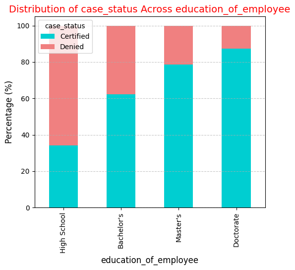

```python
plot_stacked_barplot(df, 'education_of_employee', col2 = 'case_status')
```

🔎 **Observations: Distribution of case_status Across education_of_employee**

- **Doctorate holders** have the highest certification rate at **87.23%**, indicating that highly educated applicants have a higher chance of visa approval.
- **Master's degree holders** also have a high certification rate at **78.63%**, suggesting that advanced education increases the likelihood of visa approval.
- **Bachelor's degree holders** have a moderate certification rate at **62.21%**, with a relatively high denial rate of **37.79%**.
- **High School graduates** face the lowest certification rate at **34.04%** and the highest denial rate at **65.96%**, highlighting the challenge for less-educated applicants in securing visa approval.
- The trend suggests that higher educational qualifications significantly improve the chances of visa approval.
3. **`Case Status by Full-Time Position`: To compare the distribution of full-time vs. part-time positions within certified and denied cases.**

```
case_status         Certified     Denied
full_time_position
N                   68.526044  31.473956
Y                   66.583235  33.416765
```

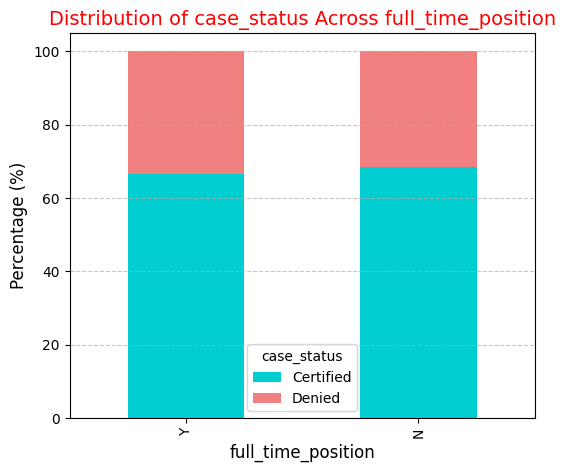

```python
plot_stacked_barplot(df, 'full_time_position', col2 = 'case_status')
```

🔎 **Observations: Distribution of case_status Across full_time_position**

- Applicants for **part-time positions (N)** have a slightly higher certification rate at **68.53%** compared to full-time positions.
- The certification rate for **full-time positions (Y)** is **66.58%**, which is slightly lower than part-time positions.
- The denial rate for **part-time positions** is **31.47%**, which is marginally lower than the denial rate for full-time positions (**33.42%**).
- Overall, the differences in certification and denial rates between full-time and part-time positions are minor, indicating that employment type may not be a strong driver of visa approval.
4. **`Case Status by Has Job Experience`: Does having prior job experience increase the chances of visa approval?**

```
case_status         Certified     Denied
has_job_experience
N                   56.134108  43.865892
Y                   74.476422  25.523578
```

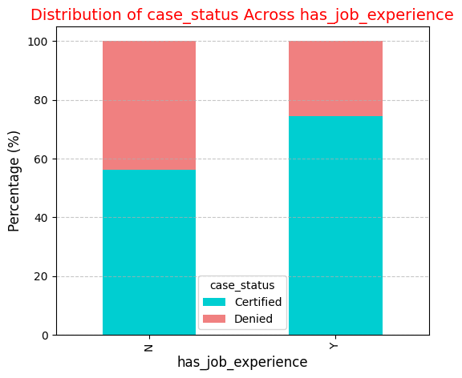

```python
plot_stacked_barplot(df, 'has_job_experience', col2 = 'case_status')
```

🔎 **Observations: Distribution of case_status Across has_job_experience**

- Applicants **with job experience (Y)** have a higher certification rate of **74.48%** compared to those without experience.
- The certification rate for applicants **without job experience (N)** is significantly lower at **56.13%**.
- The denial rate for applicants **without job experience** is high at **43.87%**, suggesting that lack of experience negatively impacts visa approval chances.
- The lower denial rate of **25.52%** for applicants **with job experience** indicates that work experience is a strong positive factor for visa approval.
- This suggests that having prior job experience significantly increases the likelihood of visa approval.
5. **`Case Status by Region of Employment`: Does the region of employment affect the chances of visa approval?**

```
case_status           Certified     Denied
region_of_employment
Island                60.266667  39.733333
Midwest               75.528210  24.471790
Northeast             62.904795  37.095205
South                 70.015676  29.984324
West                  62.253265  37.746735
```

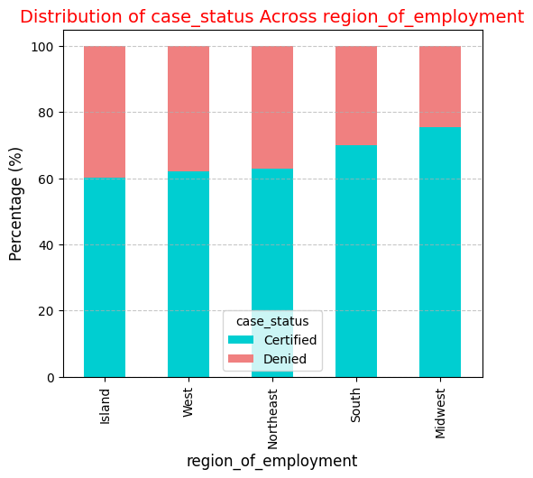

```python
plot_stacked_barplot(df, 'region_of_employment', col2 = 'case_status')
```

🔎 **Observations: Distribution of case_status Across region_of_employment**

- The **Midwest** region has the highest certification rate at **75.53%**, indicating that applicants in this region have the highest chance of visa approval.
- The **South** follows with a relatively high certification rate of **70.02%** and a lower denial rate of **29.98%**.
- The **Island** region has the lowest certification rate at **60.27%**, suggesting higher difficulty in securing visa approval in this region.
- The **West** and **Northeast** have similar certification rates at **62.25%** and **62.90%** respectively, with denial rates around **37%**.
- Overall, the **Midwest** and **South** show more favorable outcomes for visa certification compared to other regions.
6. **`Case Status by Unit of Wage`: To explore how different wage units relate to case status.**

```
case_status   Certified     Denied
unit_of_wage
Hour          34.631433  65.368567
Month         61.797753  38.202247
Week          62.132353  37.867647
Year          69.885027  30.114973
```

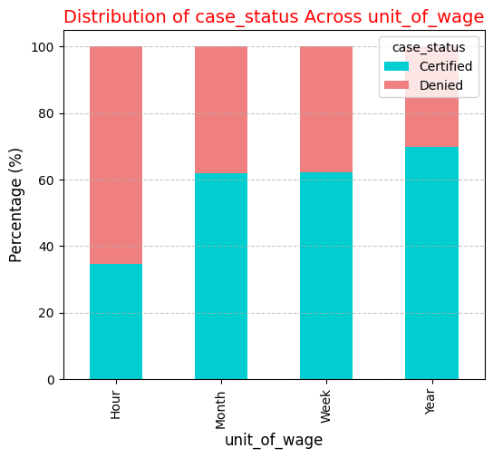

```python
plot_stacked_barplot(df, 'unit_of_wage', col2 = 'case_status')
```

🔎 **Observations: Distribution of case_status Across unit_of_wage**

- Applications with **Yearly wages** have the highest certification rate at **69.89%**, indicating that jobs offering yearly wages are more likely to result in visa approval.
- Applications with **Monthly** and **Weekly wages** have similar certification rates at **61.80%** and **62.13%** respectively, with denial rates around **38%**.
- Applications with **Hourly wages** have the lowest certification rate at **34.63%** and the highest denial rate at **65.37%**, suggesting that jobs offering hourly wages are less favorable for visa approvals.
- This indicates that jobs with **higher stability and longer-term pay structures** (e.g., yearly salaries) tend to have higher visa approval rates.
7. **`Education of Employee by Region of Employment`**

```
region_of_employment     Island    Midwest  Northeast      South       West
education_of_employee
Bachelor's             1.260504  12.849326  28.082861  29.226109  28.581200
Doctorate              1.140511  11.678832  29.927007  24.680657  32.572993
High School            1.754386  21.520468  26.461988  27.309942  22.953216
Master's               1.671165  20.759809  28.648536  26.479136  22.441354
```

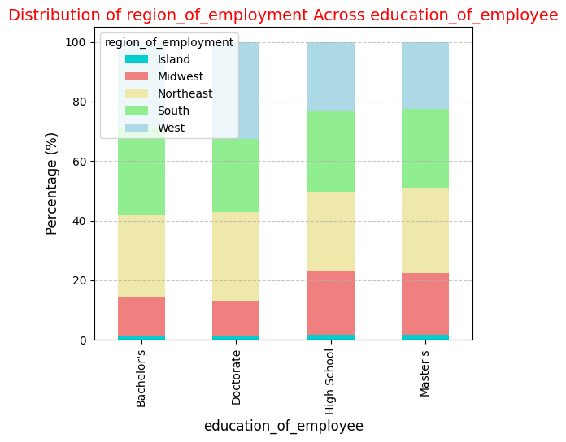

```python
ct_norm = pd.crosstab(df['education_of_employee'], df['region_of_employment'], normalize='index') * 100
print(ct_norm)
ct_norm.plot.bar(stacked=True, figsize=(6, 5), color=['darkturquoise','lightcoral','palegoldenrod','lightgreen','lightblue'])
plt.title('Distribution of region_of_employment Across education_of_employee', fontsize=14, color='red')
plt.xlabel('education_of_employee', fontsize=12)
plt.ylabel('Percentage (%)', fontsize=12)
plt.legend(title='region_of_employment', loc='best')
plt.grid(axis='y', linestyle='--', alpha=0.7)
plt.show()
```

🔎 **Observations:**

### **Visualizing Numerical v/s Categorical Data Relationships**

1. `prevailing_wage vs case_status` – Do higher wages increase the chances of visa approval?

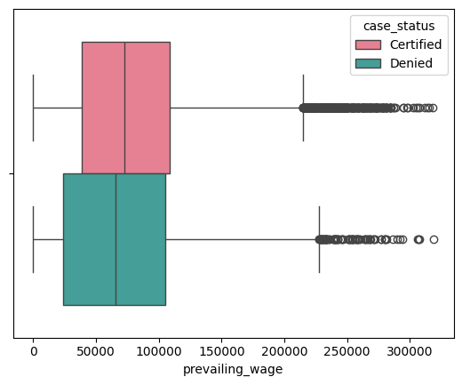

```python
sns.boxplot(data=df, x='prevailing_wage', hue='case_status');
```

🔎 **Observation:** Higher prevailing wages are generally associated with a higher likelihood of visa approval, as the median wage for certified cases is higher than that for denied cases. However, there are many outliers at higher wage levels for both certified and denied cases.

2. `prevailing_wage vs education_of_employee` – Do employees with higher education get higher wages?

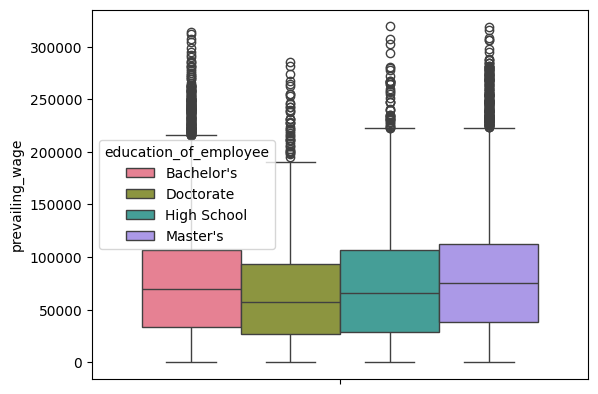

```python
sns.boxplot(data=df, y='prevailing_wage', hue='education_of_employee');
```

🔎 **Observation:** No, higher education does **not necessarily guarantee higher wages**. While employees with a **Master's degree** have the highest median wage, those with a **Doctorate** have the **lowest median wage** and a smaller wage range. Bachelor's and High School graduates have similar median wages, suggesting that higher education does not always translate into higher pay.

## 🌟 **Data Pre-Processing** 🌟

1. 🔎 **Handle Missing Values (if any)**  
   ✔️ Identify missing values and decide on an appropriate strategy.
2. 🚨 **Handle Outliers (treat, if needed- why or why not )**  
   ✔️ Detect and manage outliers.
3. 🏷️ **Encode Categorical Variables**  
   ✔️ Convert categorical variables into numerical format using:
   - **One-Hot Encoding** – For nominal data.
   - **Label Encoding** – For ordinal data.
4. 📏 **Scale Numerical Variables (if needed)**  
   ✔️ Scale numerical features to bring them to a similar range.
5. 🛠️ **Feature Engineering (if needed)**  
   ✔️ Create new features based on existing data.
6. ✂️ **Split Data into Train and Test Sets**  
   ✔️ Split the data into training and test sets using:
   - `train_test_split` (e.g., 80% training, 20% test).
7. ⚖️ **Handle Class Imbalance**  
   ✔️ Check the distribution of the target variable (`case_status`):
   - If highly imbalanced, apply:
     - **Oversampling** (SMOTE).
     - **Undersampling**.
     - **Class weights** during model training.

### 1. 🔎 **Handle Missing Values**

```python
df.isna().sum()
```

```
continent                0
education_of_employee    0
has_job_experience       0
requires_job_training    0
no_of_employees          0
yr_of_estab              0
region_of_employment     0
prevailing_wage          0
unit_of_wage             0
full_time_position       0
case_status              0
dtype: int64
```

🔎 **Observation:** Dataset does not have any null values.

### 2. 🚨 **Handle Outliers (treat, if needed- why or why not )**

🔎 **Observation:** As observed in the univariate analysis, there are outliers present in the data. However, we will retain them as they provide valuable information and could reflect meaningful variations or important patterns in the dataset.

### 3. 🏷️ **Encode Categorical Variables**

```python
# Encoding the `case_status` variable such that **Certified** is represented as `1` and **Denied** is represented as `0`
df["case_status"] = df["case_status"].apply(lambda x: 1 if x == "Certified" else 0)
```

```python
### Splitting the data into X and y
X = df.drop("case_status", axis=1)
y = df["case_status"]
```

```python
# create dummy varialbes for categories
X = pd.get_dummies(X, drop_first=True)
```

```python
X.head()
```

|  | no_of_employees | yr_of_estab | prevailing_wage | continent_Asia | continent_Europe | continent_North America | continent_Oceania | continent_South America | education_of_employee_Doctorate | education_of_employee_High School | ... | has_job_experience_Y | requires_job_training_Y | region_of_employment_Midwest | region_of_employment_Northeast | region_of_employment_South | region_of_employment_West | unit_of_wage_Month | unit_of_wage_Week | unit_of_wage_Year | full_time_position_Y |
| --- | --- | --- | --- | --- | --- | --- | --- | --- | --- | --- | --- | --- | --- | --- | --- | --- | --- | --- | --- | --- | --- |
| 0 | 14513 | 2007 | 592.2029 | True | False | False | False | False | False | True | ... | False | False | False | False | False | True | False | False | False | True |
| 1 | 2412 | 2002 | 83425.6500 | True | False | False | False | False | False | False | ... | True | False | False | True | False | False | False | False | True | True |
| 2 | 44444 | 2008 | 122996.8600 | True | False | False | False | False | False | False | ... | False | True | False | False | False | True | False | False | True | True |
| 3 | 98 | 1897 | 83434.0300 | True | False | False | False | False | False | False | ... | False | False | False | False | False | True | False | False | True | True |
| 4 | 1082 | 2005 | 149907.3900 | False | False | False | False | False | False | False | ... | True | False | False | False | True | False | False | False | True | True |

5 rows × 21 columns

### 4. ✂️ **Split Data into Train and Test Sets**

```python
# Splitting data into training, validation and test set:

# first we split data into 2 parts, say temporary and test
X_train, X_test, y_train, y_test = train_test_split(
    X, y, test_size=0.2, random_state=42, stratify=y
)

print(X_train.shape, X_test.shape)
```

```
(20384, 21) (5096, 21)
```

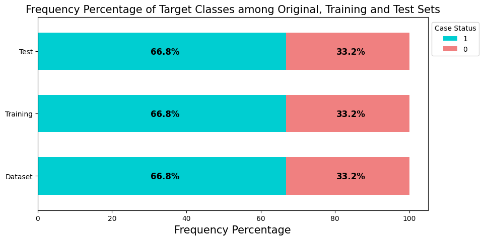

```python
# Define a dataframe containing frequency percentages
df_perc = pd.concat([y.value_counts(normalize=True).mul(100).round(1),
                     y_train.value_counts(normalize=True).mul(100).round(1),
                     y_test.value_counts(normalize=True).mul(100).round(1)], axis=1)
df_perc.columns=['Dataset','Training','Test']
df_perc = df_perc.T

colors = ['darkturquoise','lightcoral']

# Plot frequency percentages barplot
df_perc.plot(kind='barh', stacked=True, figsize=(10,5), width=0.6, color=colors)

# Add the percentages to our plot
for idx, val in enumerate([*df_perc.index.values]):
    for (percentage, y_location) in zip(df_perc.loc[val], df_perc.loc[val].cumsum()):
        plt.text(x=(y_location - percentage) + (percentage / 2)-3,
                 y=idx - 0.05,
                 s=f'{percentage}%',
                 color="black",
                 fontsize=12,
                 fontweight="bold")

plt.legend(title='Case Status', loc=(1.01,0.8))
plt.xlabel('Frequency Percentage', fontsize=15)
plt.title('Frequency Percentage of Target Classes among Original, Training and Test Sets', fontsize=15)
plt.show()
```

The training and test sets maintain the same class distribution as the original dataset, ensuring that the data split is representative of the overall population.

### 5. ⚖️ **Handle Class Imbalance**

#### **Oversampling train data using SMOTE**

```python
# Fit SMOTE on train data(Synthetic Minority Oversampling Technique)
sm = SMOTE(sampling_strategy=0.6, k_neighbors=5, random_state=43)
X_train_over, y_train_over = sm.fit_resample(X_train, y_train)

X_train_over.shape, y_train_over.shape
```

```
((21782, 21), (21782,))
```

```python
y_train.value_counts(), y_train_over.value_counts()
```

```
(case_status
 1    13614
 0     6770
 Name: count, dtype: int64,
 case_status
 1    13614
 0     8168
 Name: count, dtype: int64)
```

```python
print("Before OverSampling, value count of case_status: {} \n".format(y_train.value_counts()))
print("After OverSampling, value count of case_status: {} \n".format(y_train_over.value_counts()))

print("Before OverSampling, the shape of train_X: {}".format(X_train.shape))
print("Before OverSampling, the shape of train_y: {}\n".format(y_train.shape))

print("After OverSampling, the shape of train_X: {}".format(X_train_over.shape))
print("After OverSampling, the shape of train_y: {}".format(y_train_over.shape))
```

```
Before OverSampling, value count of case_status: case_status
1    13614
0     6770
Name: count, dtype: int64

After OverSampling, value count of case_status: case_status
1    13614
0     8168
Name: count, dtype: int64

Before OverSampling, the shape of train_X: (20384, 21)
Before OverSampling, the shape of train_y: (20384,)

After OverSampling, the shape of train_X: (21782, 21)
After OverSampling, the shape of train_y: (21782,)
```

#### **Undersampling train data using Random Undersampler**

```python
# fit random under sampler on the train data
rus = RandomUnderSampler(random_state=1, sampling_strategy = 0.6)
X_train_un, y_train_un = rus.fit_resample(X_train, y_train)

X_train_un.shape, y_train_un.shape
```

```
((18053, 21), (18053,))
```

```python
print("Before UnderSampling, value count of case_status: {} \n".format(y_train.value_counts()))
print("After UnderSampling, value count of case_status: {} \n".format(y_train_un.value_counts()))

print("Before UnderSampling, the shape of train_X: {}".format(X_train.shape))
print("Before UnderSampling, the shape of train_y: {}\n".format(y_train.shape))

print("After UnderSampling, the shape of train_X: {}".format(X_train_un.shape))
print("After UnderSampling, the shape of train_y: {}".format(y_train_un.shape))
```

```
Before UnderSampling, value count of case_status: case_status
1    13614
0     6770
Name: count, dtype: int64

After UnderSampling, value count of case_status: case_status
1    11283
0     6770
Name: count, dtype: int64

Before UnderSampling, the shape of train_X: (20384, 21)
Before UnderSampling, the shape of train_y: (20384,)

After UnderSampling, the shape of train_X: (18053, 21)
After UnderSampling, the shape of train_y: (18053,)
```

## 🌟 **Model Building - Bagging** 🌟

**Model Evaluation Criteria**

A model can err in two ways:

1. **False Positive**: The model predicts that a visa application will be approved, but in reality, it should have been rejected.
2. **False Negative**: The model predicts that a visa application will be rejected, but in reality, it should have been approved.

**Which Scenario is More Critical?**

Both scenarios carry significant implications:

- **False Positive**: If a visa is approved when it should have been denied, an unsuitable candidate might secure a job, potentially displacing a qualified U.S. citizen from that opportunity.
- **False Negative**: If a visa is denied when it should have been approved, the U.S. economy might miss out on valuable talent that could contribute to growth and innovation.

**Strategies to Minimize Errors**

```python
def model_performance_classification(model, predicators, target):
    pred = model.predict(predicators)
    precision = precision_score(target,pred)
    recall = recall_score(target,pred)
    accuracy = accuracy_score(target,pred)
    f1 = f1_score(target,pred)

    df_perf = pd.DataFrame(
        {"Accuracy": accuracy, "Recall": recall, "Precision": precision, "F1": f1,},
        index=[0],
    )

    return df_perf

def plot_confusion_matrix(model, predictors, target):
    """
    To plot the confusion_matrix with percentages

    model: classifier
    predictors: independent variables
    target: dependent variable
    """
    # Predict the target values using the provided model and predictors
    y_pred = model.predict(predictors)

    # Compute the confusion matrix comparing the true target values with the predicted values
    cm = confusion_matrix(target, y_pred)

    # Extract values from the confusion matrix
    tn, fp, fn, tp = cm.ravel()

    # Calculate total samples
    total = np.sum(cm)

    # Calculate percentages
    tp_percent = (tp / total) * 100
    tn_percent = (tn / total) * 100
    fp_percent = (fp / total) * 100
    fn_percent = (fn / total) * 100

    # Create labels for each cell in the confusion matrix with both count and percentage
    labels = np.asarray(
        [
            ["{0:0.0f}".format(item) + "\n{0:.2%}".format(item / cm.flatten().sum())]
            for item in cm.flatten()
        ]
    ).reshape(2, 2)    # reshaping to a matrix

    # Set the figure size for the plot
    plt.figure(figsize=(6, 4))

    # Plot the confusion matrix as a heatmap with the labels
    sns.heatmap(cm, annot=labels, fmt="")

    # Add a label to the y-axis
    plt.ylabel("True label")

    # Add a label to the x-axis
    plt.xlabel("Predicted label")

    # Add a title to the plot
    plt.title("Confusion Matrix for Model Performance on Test Data")

    # Print the results
    print("🔎 Observations:\n")
    print(f"1. True Positives (predicted=1, actual=1): {tp} ({tp_percent:.2f}%)")
    print(f"2. True Negatives (predicted=0, actual=0): {tn} ({tn_percent:.2f}%)")
    print(f"3. False Positives (predicted=1, actual=0): {fp} ({fp_percent:.2f}%)")
    print(f"4. False Negatives (predicted=0, actual=1): {fn} ({fn_percent:.2f}%)")

def build_model(model, X_train, y_train, X_test, y_test):
    model.fit(X_train,y_train)

    # Evaluate model performance on train & test sets
    train_perf = model_performance_classification(model, X_train, y_train)
    test_perf = model_performance_classification(model, X_test, y_test)

    print("Train Performance:\n", train_perf)
    print('\n---------------------------------\n')
    print("Confusion Matrix for Model Performance on Test Data:\n")
    plot_confusion_matrix(model, X_test, y_test)
    print('\n---------------------------------\n')
    print("Test Performance:\n", test_perf)

    return train_perf, test_perf


def tune_model(params, skf, model, X_train, y_train, X_test, y_test, scoring='f1', n_iter=30):
    """
    Performs hyperparameter tuning using RandomizedSearchCV, evaluates with cross-validation,
    and returns model performance on train & test sets.

    Parameters:
        params (dict): Hyperparameter grid for RandomizedSearchCV
        skf (KFold or StratifiedKFold): Cross-validation strategy
        model (sklearn model): Base model to be tuned
        X_train (pd.DataFrame): Training predictors
        y_train (pd.Series): Training target
        X_test (pd.DataFrame): Test predictors
        y_test (pd.Series): Test target
        scoring (str): Metric to optimize during RandomizedSearchCV (default: 'f1')
        n_iter (int): Number of iterations for RandomizedSearchCV (default: 30)

    Returns:
        dict: Contains best parameters, cross-validation scores, train & test performance
    """

    # Perform RandomizedSearchCV without refitting
    random_search = RandomizedSearchCV(
        estimator=model, param_distributions=params,
        n_iter=n_iter, cv=skf, scoring=scoring,
        verbose=2, n_jobs=-1, random_state=42, refit=True
    )

    # Fit on training data
    random_search.fit(X_train, y_train)

    # Get best hyperparameters
    best_params = random_search.best_params_
    print("Best Parameters:", best_params)
    print('\n---------------------------------\n')

    # Step 4: Compute cross-validation scores (using best model)
    cv_scores = cross_val_score(random_search, X_train, y_train, cv=skf, scoring=scoring, n_jobs=-1)
    print(f"Mean cross-validation {scoring} score: {cv_scores.mean()}")
    print('\n---------------------------------\n')

    # Evaluate model performance on train & test sets
    train_perf = model_performance_classification(random_search, X_train, y_train)
    test_perf = model_performance_classification(random_search, X_test, y_test)

    print("Train Performance:\n", train_perf)
    print('\n---------------------------------\n')
    print("Confusion Matrix for Model Performance on Test Data:\n")
    plot_confusion_matrix(random_search, X_test, y_test)
    print('\n---------------------------------\n')
    print("Test Performance:\n", test_perf)

    return {
        "best_model" : random_search,
        "best_params": best_params,
        "cv_scores": cv_scores,
        "train_performance": train_perf,
        "test_performance": test_perf
    }
```

```python
# defining Stratifiedkfold
# number of splits = 5
skfold = StratifiedKFold(n_splits=5, random_state=42, shuffle = True)
```

#### **1. Decision Tree (sklearn default)**

`1. Original Data`

```
Train Performance:
    Accuracy  Recall  Precision   F1
0       1.0     1.0        1.0  1.0

---------------------------------

Confusion Matrix for Model Performance on Test Data:

🔎 Observations:

1. True Positives (predicted=1, actual=1): 2509 (49.23%)
2. True Negatives (predicted=0, actual=0): 821 (16.11%)
3. False Positives (predicted=1, actual=0): 871 (17.09%)
4. False Negatives (predicted=0, actual=1): 895 (17.56%)

---------------------------------

Test Performance:
    Accuracy    Recall  Precision        F1
0  0.653454  0.737074   0.742308  0.739682
```

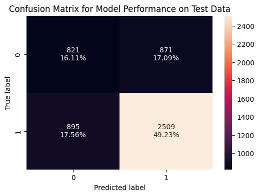

```python
# creating an instance of the decision tree model
dtree1 = DecisionTreeClassifier(random_state=42)
dtree1_train_perf, dtree1_test_perf = build_model(dtree1, X_train, y_train, X_test, y_test)
```

🔎 **`Observations:`** The model is **overfitting**, achieving perfect performance on the train set but significantly lower accuracy and F1-score on the test set, indicating poor generalization.

`2. Oversampled Data`

```
Train Performance:
    Accuracy  Recall  Precision   F1
0       1.0     1.0        1.0  1.0

---------------------------------

Confusion Matrix for Model Performance on Test Data:

🔎 Observations:

1. True Positives (predicted=1, actual=1): 2501 (49.08%)
2. True Negatives (predicted=0, actual=0): 848 (16.64%)
3. False Positives (predicted=1, actual=0): 844 (16.56%)
4. False Negatives (predicted=0, actual=1): 903 (17.72%)

---------------------------------

Test Performance:
    Accuracy    Recall  Precision        F1
0  0.657182  0.734724   0.747683  0.741147
```

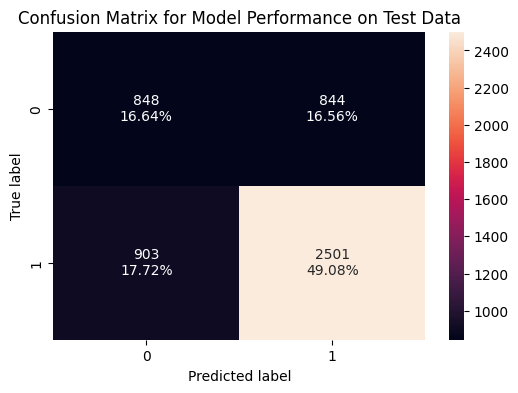

```python
# creating an instance of the decision tree model
dtree1_over = DecisionTreeClassifier(random_state=42)
dtree1_over_train_perf, dtree1_over_test_perf = build_model(dtree1_over, X_train_over, y_train_over, X_test, y_test)
```

🔎 **`Observations:`** The model is **overfitting**, as it achieves perfect performance on the train set but shows a drop in all metrics on the test set, indicating poor generalization.

`3. Undersampled Data`

```
Train Performance:
    Accuracy  Recall  Precision   F1
0       1.0     1.0        1.0  1.0

---------------------------------

Confusion Matrix for Model Performance on Test Data:

🔎 Observations:

1. True Positives (predicted=1, actual=1): 2413 (47.35%)
2. True Negatives (predicted=0, actual=0): 907 (17.80%)
3. False Positives (predicted=1, actual=0): 785 (15.40%)
4. False Negatives (predicted=0, actual=1): 991 (19.45%)

---------------------------------

Test Performance:
    Accuracy    Recall  Precision        F1
0  0.651491  0.708872   0.754534  0.730991
```

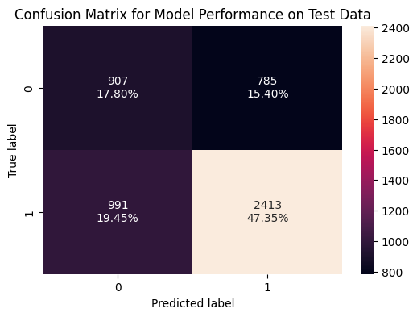

```python
# creating an instance of the decision tree model
dtree1_un = DecisionTreeClassifier(random_state=42)
dtree1_un_train_perf, dtree1_un_test_perf = build_model(dtree1_un, X_train_un, y_train_un, X_test, y_test)
```

🔎 **`Observations:`** The model shows signs of overfitting.

##### **Model Performance Comparison**

```python
# default model performance comparison

models_train_comp_df = pd.concat(
    [
        dtree1_train_perf.T,
        dtree1_test_perf.T,
        dtree1_over_train_perf.T,
        dtree1_over_test_perf.T,
        dtree1_un_train_perf.T,
        dtree1_un_test_perf.T,
    ],
    axis=1,
)
models_train_comp_df.columns = [
    "Original Data - Train Perf",
    "Original Data - Test Perf",
    "Oversampled Data - Train Perf",
    "Oversampled Data - Test Perf",
    "Undersampled Data - Train Perf",
    "Undersampled Data - Test Perf",
]
print("Training performance comparison:")
models_train_comp_df
```

```
Training performance comparison:
```

|  | Original Data - Train Perf | Original Data - Test Perf | Oversampled Data - Train Perf | Oversampled Data - Test Perf | Undersampled Data - Train Perf | Undersampled Data - Test Perf |
| --- | --- | --- | --- | --- | --- | --- |
| Accuracy | 1.0 | 0.653454 | 1.0 | 0.657182 | 1.0 | 0.651491 |
| Recall | 1.0 | 0.737074 | 1.0 | 0.734724 | 1.0 | 0.708872 |
| Precision | 1.0 | 0.742308 | 1.0 | 0.747683 | 1.0 | 0.754534 |
| F1 | 1.0 | 0.739682 | 1.0 | 0.741147 | 1.0 | 0.730991 |

🔎 **`Observations:`**

1. **Original Data:** The model shows signs of overfitting, with perfect performance on the train set but a significant drop in test performance.
2. **Oversampled Data:** The model performs slightly better on the test set compared to the original data, indicating better generalization.
3. **Undersampled Data:** The test performance is the lowest among the three, suggesting that undersampling may have led to loss of important information.

#### **2. Bagging Classifier**

`1. Original Data`

```
Train Performance:
    Accuracy    Recall  Precision        F1
0  0.983271  0.984207   0.990684  0.987435

---------------------------------

Confusion Matrix for Model Performance on Test Data:

🔎 Observations:

1. True Positives (predicted=1, actual=1): 2593 (50.88%)
2. True Negatives (predicted=0, actual=0): 931 (18.27%)
3. False Positives (predicted=1, actual=0): 761 (14.93%)
4. False Negatives (predicted=0, actual=1): 811 (15.91%)

---------------------------------

Test Performance:
    Accuracy    Recall  Precision        F1
0  0.691523  0.761751   0.773107  0.767387
```

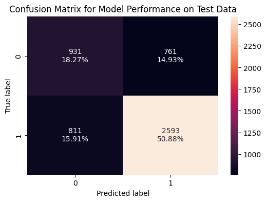

```python
#base_estimator for bagging classifier is a decision tree by default
bag1=BaggingClassifier(random_state=1)
bag1_train_perf, bag1_test_perf = build_model(bag1, X_train, y_train, X_test, y_test)
```

🔎 **`Observations:`** The model is performing well on the test set with decent generalization, though there is a noticeable gap between train and test performance, indicating potential overfitting.

`2. Oversampled Data`

```
Train Performance:
    Accuracy   Recall  Precision        F1
0  0.984666  0.98362   0.991779  0.987683

---------------------------------

Confusion Matrix for Model Performance on Test Data:

🔎 Observations:

1. True Positives (predicted=1, actual=1): 2583 (50.69%)
2. True Negatives (predicted=0, actual=0): 928 (18.21%)
3. False Positives (predicted=1, actual=0): 764 (14.99%)
4. False Negatives (predicted=0, actual=1): 821 (16.11%)

---------------------------------

Test Performance:
    Accuracy    Recall  Precision       F1
0  0.688972  0.758813   0.771736  0.76522
```

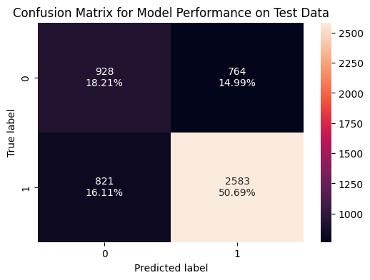

```python
bag1_over=BaggingClassifier(random_state=1)
bag1_over_train_perf, bag1_over_test_perf = build_model(bag1_over, X_train_over, y_train_over, X_test, y_test)
```

🔎 **`Observations:`** The model performs well on the training set but shows a drop in performance on the test set, indicating a potential overfitting issue.

`3. Undersampled Data`

```
Train Performance:
    Accuracy    Recall  Precision        F1
0  0.982219  0.981033   0.990426  0.985707

---------------------------------

Confusion Matrix for Model Performance on Test Data:

🔎 Observations:

1. True Positives (predicted=1, actual=1): 2504 (49.14%)
2. True Negatives (predicted=0, actual=0): 1004 (19.70%)
3. False Positives (predicted=1, actual=0): 688 (13.50%)
4. False Negatives (predicted=0, actual=1): 900 (17.66%)

---------------------------------

Test Performance:
    Accuracy    Recall  Precision        F1
0  0.688383  0.735605   0.784461  0.759248
```

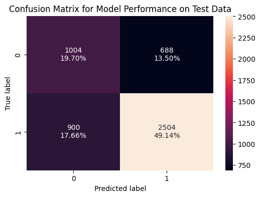

```python
bag1_un=BaggingClassifier(random_state=1)
bag1_un_train_perf, bag1_un_test_perf = build_model(bag1_un, X_train_un, y_train_un, X_test, y_test)
```

🔎 **`Observations:`** The model performs well on the training data, achieving high accuracy, recall, precision, and F1-score. However, on the test data, there is a noticeable drop in performance, particularly in recall and accuracy, indicating potential overfitting and a need for better generalization.

##### **Bagging Classifier Performance Comparison**

```python
# default model performance comparison

models_train_comp_df = pd.concat(
    [
        bag1_train_perf.T,
        bag1_test_perf.T,
        bag1_over_train_perf.T,
        bag1_over_test_perf.T,
        bag1_un_train_perf.T,
        bag1_un_test_perf.T,
    ],
    axis=1,
)
models_train_comp_df.columns = [
    "Original Data - Train Perf",
    "Original Data - Test Perf",
    "Oversampled Data - Train Perf",
    "Oversampled Data - Test Perf",
    "Undersampled Data - Train Perf",
    "Undersampled Data - Test Perf",
]
print("Training performance comparison:")
models_train_comp_df
```

```
Training performance comparison:
```

|  | Original Data - Train Perf | Original Data - Test Perf | Oversampled Data - Train Perf | Oversampled Data - Test Perf | Undersampled Data - Train Perf | Undersampled Data - Test Perf |
| --- | --- | --- | --- | --- | --- | --- |
| Accuracy | 0.983271 | 0.691523 | 0.984666 | 0.688972 | 0.982219 | 0.688383 |
| Recall | 0.984207 | 0.761751 | 0.983620 | 0.758813 | 0.981033 | 0.735605 |
| Precision | 0.990684 | 0.773107 | 0.991779 | 0.771736 | 0.990426 | 0.784461 |
| F1 | 0.987435 | 0.767387 | 0.987683 | 0.765220 | 0.985707 | 0.759248 |

🔎 **`Observations:`**

#### **3. Random Forest Classifier**

`1. Original Data`

```
Train Performance:
    Accuracy  Recall  Precision   F1
0       1.0     1.0        1.0  1.0

---------------------------------

Confusion Matrix for Model Performance on Test Data:

🔎 Observations:

1. True Positives (predicted=1, actual=1): 2868 (56.28%)
2. True Negatives (predicted=0, actual=0): 837 (16.42%)
3. False Positives (predicted=1, actual=0): 855 (16.78%)
4. False Negatives (predicted=0, actual=1): 536 (10.52%)

---------------------------------

Test Performance:
    Accuracy    Recall  Precision        F1
0  0.727041  0.842538   0.770346  0.804827
```

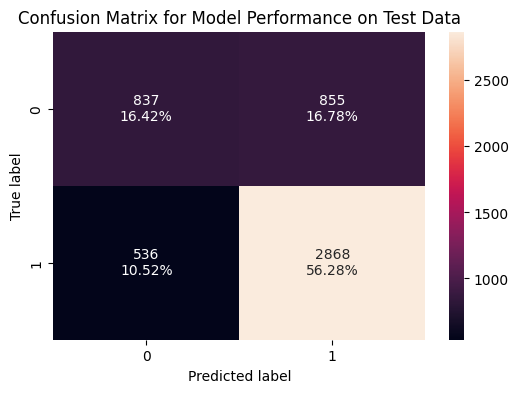

```python
#Train the random forest classifier
rf1=RandomForestClassifier(random_state=42)
rf1_train_perf, rf1_test_perf = build_model(rf1, X_train, y_train, X_test, y_test)
```

🔎 **Observations:** The model achieves perfect performance on the training data but experiences a significant drop in accuracy on the test data, suggesting potential overfitting, despite maintaining a relatively balanced recall and precision on the test set.

`2. Oversampled Data`

```
Train Performance:
    Accuracy  Recall  Precision   F1
0       1.0     1.0        1.0  1.0

---------------------------------

Confusion Matrix for Model Performance on Test Data:

🔎 Observations:

1. True Positives (predicted=1, actual=1): 2837 (55.67%)
2. True Negatives (predicted=0, actual=0): 837 (16.42%)
3. False Positives (predicted=1, actual=0): 855 (16.78%)
4. False Negatives (predicted=0, actual=1): 567 (11.13%)

---------------------------------

Test Performance:
    Accuracy    Recall  Precision        F1
0  0.720958  0.833431   0.768418  0.799605
```

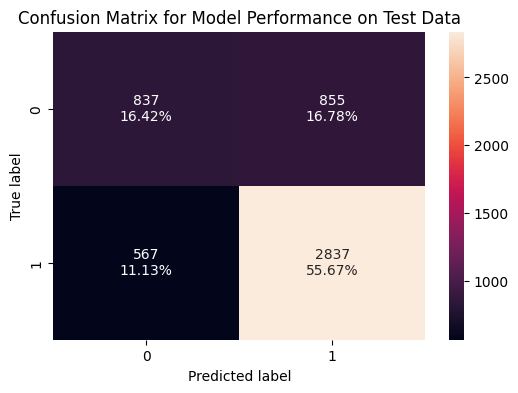

```python
rf1_over=RandomForestClassifier(random_state=42)
rf1_over_train_perf, rf1_over_test_perf = build_model(rf1_over, X_train_over, y_train_over, X_test, y_test)
```

🔎 **Observations:** The model demonstrates perfect performance on the training data but shows a notable decrease in accuracy and other metrics on the test data, indicating overfitting, though it still maintains a reasonable balance between recall and precision on unseen data.

`3. Undersampled Data`

```
Train Performance:
    Accuracy    Recall  Precision        F1
0  0.999889  0.999823        1.0  0.999911

---------------------------------

Confusion Matrix for Model Performance on Test Data:

🔎 Observations:

1. True Positives (predicted=1, actual=1): 2717 (53.32%)
2. True Negatives (predicted=0, actual=0): 933 (18.31%)
3. False Positives (predicted=1, actual=0): 759 (14.89%)
4. False Negatives (predicted=0, actual=1): 687 (13.48%)

---------------------------------

Test Performance:
    Accuracy    Recall  Precision        F1
0  0.716248  0.798179   0.781646  0.789826
```

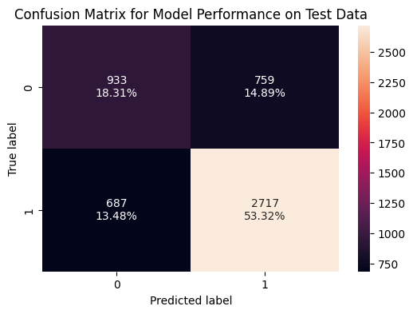

```python
rf1_un = RandomForestClassifier(random_state=42)
rf1_un_train_perf, rf1_un_test_perf = build_model(rf1_un, X_train_un, y_train_un, X_test, y_test)
```

🔎 **Observations:** The model exhibits near-perfect performance on the training data but experiences a significant drop in accuracy and other metrics on the test data, indicating overfitting.

##### **Random Forest Classifier Performance Comparison**

```python
# default model performance comparison

models_train_comp_df = pd.concat(
    [
        rf1_train_perf.T,
        rf1_test_perf.T,
        rf1_over_train_perf.T,
        rf1_over_test_perf.T,
        rf1_un_train_perf.T,
        rf1_un_test_perf.T,
    ],
    axis=1,
)
models_train_comp_df.columns = [
    "Original Data - Train Perf",
    "Original Data - Test Perf",
    "Oversampled Data - Train Perf",
    "Oversampled Data - Test Perf",
    "Undersampled Data - Train Perf",
    "Undersampled Data - Test Perf",
]
print("Training performance comparison:")
models_train_comp_df
```

```
Training performance comparison:
```

|  | Original Data - Train Perf | Original Data - Test Perf | Oversampled Data - Train Perf | Oversampled Data - Test Perf | Undersampled Data - Train Perf | Undersampled Data - Test Perf |
| --- | --- | --- | --- | --- | --- | --- |
| Accuracy | 1.0 | 0.727041 | 1.0 | 0.720958 | 0.999889 | 0.716248 |
| Recall | 1.0 | 0.842538 | 1.0 | 0.833431 | 0.999823 | 0.798179 |
| Precision | 1.0 | 0.770346 | 1.0 | 0.768418 | 1.000000 | 0.781646 |
| F1 | 1.0 | 0.804827 | 1.0 | 0.799605 | 0.999911 | 0.789826 |

🔎 **`Observations:`**